# What influences model results

2020-07-20 19:44:43

## Uncertainty in model results

- Model results have different sources of uncertainty attached to them.
- Not all types of uncertainty are always explicitly acknowledged.
- That’s true not only for mathematical/computer models.

## Structural Uncertainty

- Models are simplifications and abstractions of the real world.
- Specific assumptions lead to different models.
- Every model is ‘wrong’ in some sense, but some might be useful.
- We need to decide which variables and processes to include and which to exclude.

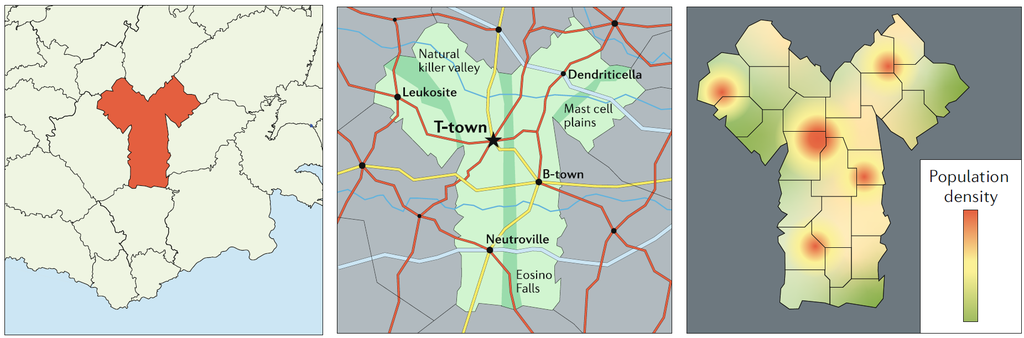

## Structural Uncertainty

- Include certain variables/components not?
- How to formulate mechanisms/processes?
- What type of model? (ODE, IBM, etc.)

## Example variants of specific processes

Exponential or Linear growth? Mass-action or saturating killing?

\[ \begin{aligned} \dot{B} & = g B - d_B B - kBI\\ \dot{I} & = r BI - d_I I \\ \\ \dot{B} & = g - d_B B - k\frac{B}{B+s}I\\ \dot{I} & = r BI - d_I I \\ \end{aligned} \]

## Structural Uncertainty Example

Dobrovolny et al. (2013 PLoS One) compared different influenza models and assessed how they matched experimental data.

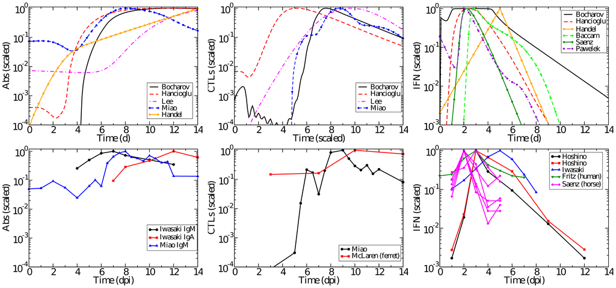

Top: models, bottom: data

## Structural Uncertainty - Summary

- The biggest source of variability in outcomes.
- No systematic way to deal with it.
- Often discussed/addressed the least. Comparison of results across models is rare.
- Topical example: https://www.cdc.gov/coronavirus/2019-ncov/covid-data/forecasting-us.html

## Structural Uncertainty - Practice

- The *Model variant exploration* app in DSAIRM explores the impact of different model formulations.

## Parameter Uncertainty

## Parameter Uncertainty

- Assume we chose a certain structure for our model and built it (e.g. a certain set of ordinary differential equations).
- To explore the model or make predictions, we need to supply it with values for the model parameters (and starting conditions).
- Often, we do not know the values for the model parameters very well.

\[ \begin{aligned} \dot{B} & = g B - d_B B - kBI\\ \dot{I} & = r BI - d_I I \\ \end{aligned} \]

## Exploring the impact of model parameters

- Sometimes we can obtain estimates for parameter values from fitting to data, but the right data is often not available.
- Instead of running our model for just one set of parameter values, we could run it using different values that are within reasonable ranges.
- If we have a small model, we could systematically explore model behavior for each parameter.

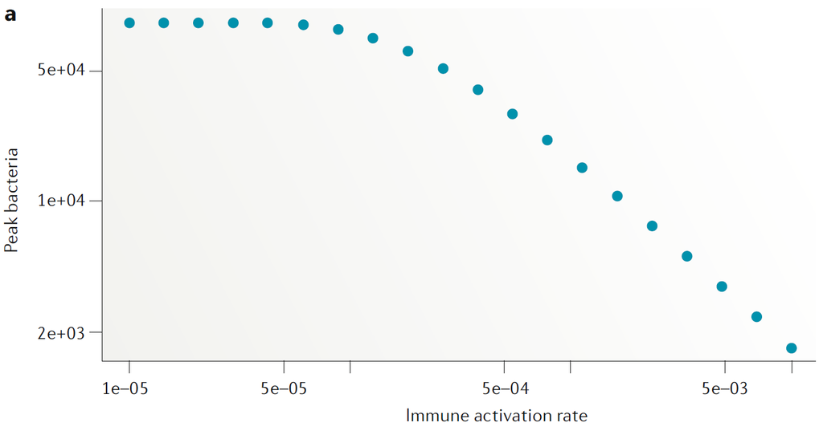

## Exploring the impact of model parameters

- Once models get big, it would take too long to thoroughly scan over all parameters.
- Often we can get reasonable ranges from the literature, but not exact values.
- Sometimes, we might be *mainly* interested in how results change as we vary one parameter, but we also want to know how uncertainty in other parameters affect our outcome.
- Other times, we might want to use our model to make predictions. We need to figure out how uncertainty in parameters affects our predictions.

## Uncertainty & Sensitivity Analysis

Varying multiple inputs/parameters over a usually broad range is called a (global) uncertainty & sensitivity analysis.

- **Uncertainty Analysis:** Given uncertainty in the inputs (parameters), how much uncertainty is there in the outputs/results?
- **Sensitivity Analysis:** How much do individual inputs contribute to the uncertainty in outputs/results?

## Doing Uncertainty & Sensitivity Analysis

- Determine ranges of uncertainty for each input (parameter and initial conditions).
- Repeatedly draw samples of parameter values from the specified distributions.
- Run model for each parameter sample, record outcomes.

## Parameter ranges

For each parameter, specify its distribution:

- Single value if we are very certain.
- Uniform distribution between some min and max values if we know very little.
- A ‘peaked’ distribution (e.g. gamma, log-normal) if we are fairly certain about some parameters.

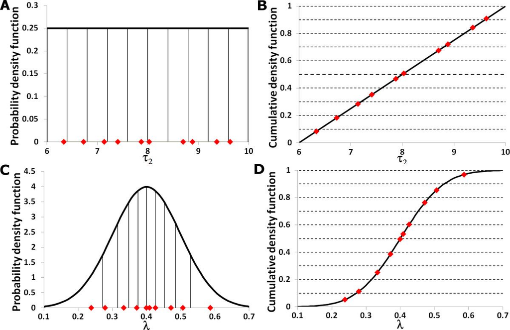

Hoare et al 2008 TBMM

## Parameter sampling

- Exhaustively trying all parameter value combinations takes too long.
- Randomly sampling is not efficient, it might leave areas of parameter space unexplored.
- A method called Latin Hypercube Sampling creates samples that efficiently span the parameter space.

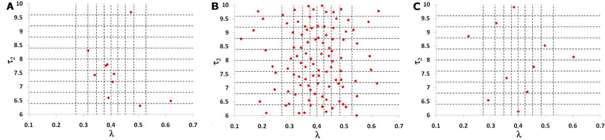

Hoare et al 2008 TBMM

## Uncertainty Analysis

- Sample over parameters, record outcomes for each sample.
- Show the uncertainty in outcomes due to uncertainty in parameters with e.g. a boxplot

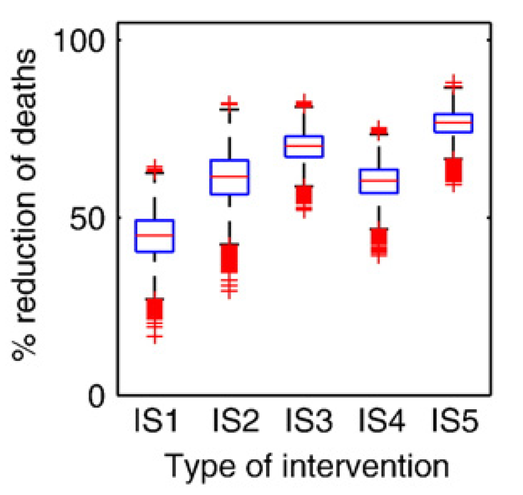

Example of a boxplot for some U/S analysis. For different intervention strategies (along the x-axis), samples are run and some outcome is recorded.

## Sensitivity Analysis

- Uncertainty analysis tells us how uncertainty in inputs affects uncertainty in outputs.
- If we want to know in more detail how a specific input affects a specific output, we can move on to sensitivity analysis.
- Using the same simulation results, we now plot scatterplots for income/outcome pairs of interest instead of boxplots.

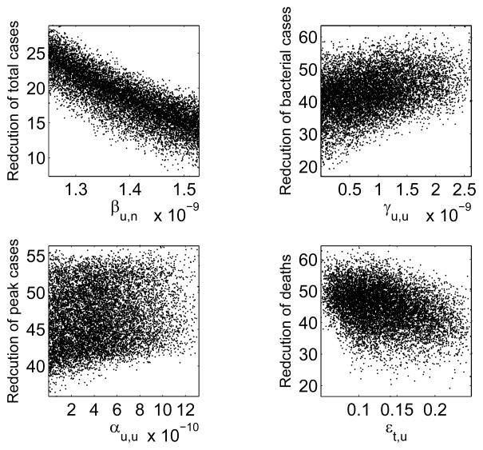

Handel et al (2009), Epidemics

## U/S Analysis - Summary

- Uncertainty in parameters can be fairly easily quantified.
- By sampling over parameters, one can obtain confidence intervals or similar measures of uncertainty.
- **This does not account for structural or inherent uncertainty!**

## Parameter uncertainty - Practice

- The *U/S analysis* app explores the concept in more detail.

## Inherent/Stochastic Uncertainty

## Introduction

- Deterministic models (both continuous and discrete-time) give you the same result for a set of parameters and starting conditions no matter how often you run them.
- Real systems are stochastic/random, which means they have some inherent variability.
- The words Stochasticity, Randomness, Noise, Variability are often used interchangably.

## Sources of Stochasticity

- Random (external) noise (e.g. measurement error).
- Fluctuations in parameters (e.g. due to temperature or circadian rythms).
- Unpredictability of event occurence (e.g. births, deaths).

## When is stochasticity important

- For small numbers.
- When we want to answer questions such as “What is the probability that X will happen?”

## Stochastic compartmental models

We can fairly easily formulate any compartmental model (e.g. and ODE model) as a stochastic model.

- All variables take on discrete values (0,1,2,…).
- Increases or decreases are dicated by inflows and outflows.
- At each time step, one of the possible inflows/outflows occurs, with probability based on the size of the term.

## Some terminology

- The events that happen are often called reactions or transitions.
- The inflow and outflow terms are called propensities, multiplied by the time step they are probabilities.

## Example

\[ \begin{aligned} \textrm{Uninfected Cells} \qquad \dot{U} & = n -d_U U - bUV \\ \textrm{Infected Cells} \qquad \dot{I} & = bUV - d_I I \\ \textrm{Virus} \qquad \dot{V} & = pI - d_V V - b UV \end{aligned} \]

| Event type | Transitions | Propensity |
| --- | --- | --- |
| Production of U | U => U+1 | n |
| death/removal of U | U => U-1 | \(d_U\)U |
| infection | U => U-1, V => V-1, I => I+1 | bUV |
| death if I | I => I-1 | \(d_I\)I |
| production of V | V => V+1 | pI |
| removal of V | V => V-1 | \(d_V\)V |

## Comments

- Stochastic models are not much harder to implement, but they require more computational time since we need to run ensembles.
- One can fit stochastic models to data, but that’s tricky and takes a long time.
- The `adaptivetau` package in R makes implementing stochastic models easy.
- The `pomp` package in R is a good tool for fitting stochastic models.

## Stochastic uncertainty - Practice

- The apps in the *Stochastic models* section of DSAIDE provide more details.
- The *Stochastic Model* and *Influenza antivirals and resistance* apps in DSAIRM illustrate stochastic models.

## Summary

- Uncertainty in modeling results can come from different sources.
- Structural uncertainty is arguably the most important but rarely explored. (Similar problems exist outside of modeling, e.g. how good a model are mice or elite undergrad students for the general population?)
- Parameter uncertainty is increasingly included in modeling projects and should be explored if a model is used for prediction.
- Stochastic models are also becoming more common but are still somewhat harder to work with.